# **Evaluation of a potentially optimal location for an official store in Sydney**

### Project 3

### University of Sydney | Foundation of Data Science | May 2023

## Client

### [**Dear Klairs**](https://www.klairscosmetics.com)

- A Korean skincare brand established in 2010
- Currently has 1,000 distribution channels in 40 countries
- Aims at becoming a global brand

## Recommendations

- The proximity of light rail stations is a reasonable location for Dear Klairs’ official store in Sydney.
- Light rail stations in the middle of the Sydney light rail network appears to be the best option.
- The second and third best choices are those in the Eastern and Western part of the network, respectively.

## Evidence

### [The Data](https://opendata.transport.nsw.gov.au/dataset/opal-trips-light-rail)

- 47 light rail stations from opendata.transport.nsw.gov.au, with 3 variables in consideration:
  - Month and Year recorded
  - Name of the light rail stations
  - Trips
- Closed light rail stations were excluded, considering only the stations which are currently operated

### Is the number of people accessing light rail affected by the temperature?

[interactive chart not shown]

*Table 1: Welch’s Test on The difference between Average Light Rail Trips in Low and High Temperature*

##### Technical Notes

- Hypothesis:
  - H<sub>0</sub>: warm months’ average light rail trips - cold months’ average light rail trips = 0
  - H<sub>1</sub>: warm months’ average light rail trips - cold months’ average light rail trips ≠ 0
- Significance level: 0.05
- p-value: 0.89 > 0.05

-> H<sub>0</sub> is retained

### Which part of the light rail network in Sydney is the most crowded?

- The light rail network in Sydney is divided into three parts: Western, Central, and Eastern as demonstrated in Figure 1.

[figure not shown]

Figure 1: The division of light rail network in Sydney

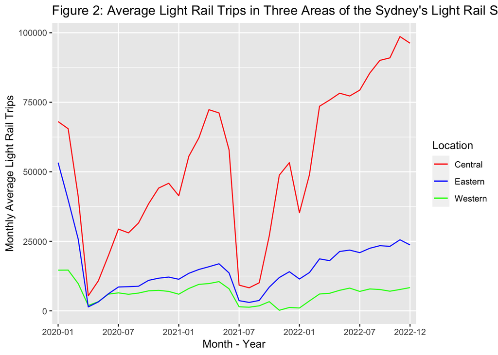

## Acknowledgements

Data transformation with dplyr cheatsheet. (2021, January 7). Posit. Retrieved May 21, 2023, from https://posit.co/wp-content/uploads/2022/10/data-transformation-1.pdf

Data visualization with ggplot2 cheatsheet. (2021, January 8). Posit. Retrieved May 21, 2023, from https://posit.co/wp-content/uploads/2022/10/data-visualization-1.pdf

Dear, Klairs. (2023, March 31). Dear, Klairs | Vegan-Friendly, Cruelty-Free, Korean Skincare. https://www.klairscosmetics.com/

Dynamic documents with rmarkdown cheatsheet. (2021, January 8). Posit. Retrieved May 21, 2023, from https://posit.co/wp-content/uploads/2022/10/rmarkdown-1.pdf

Ed Discussion #1021. (2023, May). Edstem.org. Retrieved May 21, 2023, from https://edstem.org/au/courses/10756/discussion/1347688

Laherty, J. (2022). Evaluation of Top Performing Publishing Houses Since 2000. Retrieved May 21, 2023, from https://canvas.sydney.edu.au/courses/48435/files/29946345?wrap=1

Light Rail Network Map | TfNSW Open Data Hub and Developer Portal. (n.d.). https://opendata.transport.nsw.gov.au/dataset/opal-trips-light-rail/resource/58fd604c-67b6-4878-96c3-5b5c25b95cd6

Opal Trips - Light Rail | TfNSW Open Data Hub and Developer Portal. (n.d.). https://opendata.transport.nsw.gov.au/dataset/opal-trips-light-rail

Sydney climate: Average Temperature, weather by month, Sydney water temperature - Climate-Data.org. (n.d.-b). https://en.climate-data.org/oceania/australia/new-south-wales/sydney-24/#

Drop in session - Wednesday 17th May, 2023

DATA1001 Lecture - Topic 10: Test for Mean - Discover videos

## Appendix

### Client

Dear, Klairs aims to become a global skincare brand but has only one distributor in Sydney. Regarding their target, I believe they would love to have a store location that could maximize their brand awareness, thus making them a potential client for my research. Considering Dear, Klairs as my client, I have provided evidence on the stable access to Sydney light rail stations, which seems unreadily available for such a Korean brand. I have also utilized less technical language in this report to make it understandable for this cosmetic firm.

### Statistical Analytics

[interactive chart not shown]

*Table 2: Variance Test on the Spread of the Average Light Rail Trips in Cold and Warm months*

- The number of people accessing light rail during cold seasons does not affect their warm-season counterparts and vice versa.
- Due to the Central Limit Theorem, the distribution is normal in both cold and warm months.
- A line graph is suitable for comparing objects through a period of time.

### Limitations

- Inconsistent tapping behaviors could lead to the incompleteness of the data.
- The actual daily temperature might be inconsistent with the assumed monthly average temperature.